# UFO Sightings Interactive Dashboard

UFOs! Unidentified Flying Objects have been a national conspiracy for decades in the US, popularized in media by events like the Roswell incident in New Mexico and the War of the Worlds radio broadcast of 1938. Since these events, are there any patterns that emerge in UFO observation data that can be used to draw inferences on the frequencies, types, times, and locations of sighting? The column to the right proposes three research questions for such data exploration.

Data were collected from the Tidy Tuesday github repository from a 2023 updated version of the 2019 UFO data sets. Files for both full sighting descriptions and geographic location of encounter were used. Data were filtered to include only US sightings, with Alaska and Hawaii dropped to emphasize the contiguous US. Outside 2020 census data was utilized for sightings-to-population comparisons, and integrated with the “sightings by US state” data set.

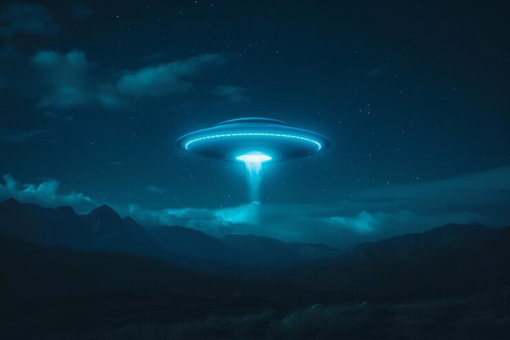

Source:Freepik

Research Questions

What are the most common UFO shapes/types reported?

Q1

What time of day are UFOs most frequently seen?

Q2

What U.S. states are the most/least likely to report UFOs?

Q3

**What are the most common UFO types/shapes?**

- The bar plot shows the square-root transformed total observations of various UFO shapes/types. They descriptions range in various ways, from overall geometry, to physical state.
- The most common UFO type reported is “light”, with 17295 total observations, followed by “circle” (8554 observations) and “triangle” (8280 observations). The least observed UFO type is “cube”, with only two observations.
- Does the large frequency of “light” observations reveal insights for either geospatial observations in the US or observations for different times of day? The following visualizations investigate this further.

Occurrence of Shapes/Types Descriptions for UFOs

[interactive chart not shown]

**What times of day are UFOs most reported?** The radial bar plot display the square-root transformed total count of observations at a given day part. For differentiating the dusks and dawns, “astronomical” is closest to night, “civil” is closest to morning/afternoon, and “nautical” is in between astronomical and civil.

- The plot signifies the cyclic nature of time and the trend of observations throughout the day, and the chosen color mapping represent sky colors in the day-night cycle.
- From the plot, we see the most frequent time of observation is night (43721 observations), followed by afternoon (11348 observations), astronomical dusk (9408 observations), and nautical dusk (7009 observations).

Total Observations Throughout the Day

[interactive chart not shown]

Implications

The below animation cycles through the total observations for day parts by object type.

- While night sightings are the dominant trend for most UFO types, when silhouette geometries (stars, cigars, disks) are displayed, they have more afternoon and daytime observations comparatively to light types (light, flash, formation).
- This makes sense given light sightings would be more noticeable at later hours/night.

Day Part Observations by Shape

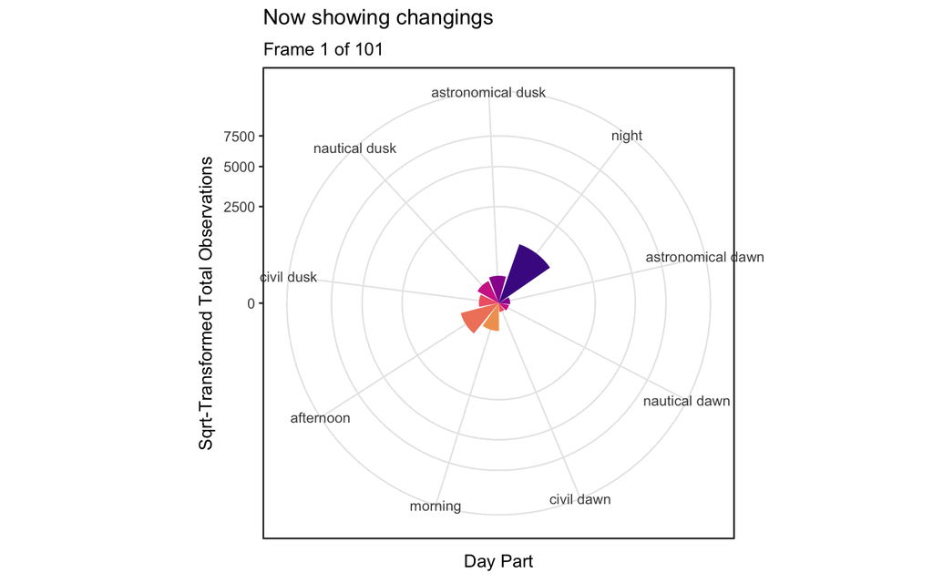

Data, Metric, and Scale

**What US states are UFOs most/least reported?**

- To ensure state population density does not misrepresent the likelihood of UFO encounter, the latest census information for state populations was used to compare the total observations in a state with its respective total population size. Since the total observations are from an all-time list ranging as far back as 1947, and the state population data is from the latest census (2020), the assumption that the growth rate in each state has remained the same over time is being taken into consideration.
- The metric used for estimating encounter probability was calculated by dividing total state sightings by total state population, represented as a 1 in (some number) probability of encounter in specified state.
- The scale represent the 1 in log-transformed probability of UFO encounter with consideration to population. **Bluer** values indicate that UFO sightings are more likely in that state, and **yellower** values indicates a lower likelihood of UFO encounter in that state.

All-Time UFO Observations for the Lower 48

[interactive chart not shown]

- Based on the choropleth, there seems to be a pattern in the continental US that rural, higher equatorial states are more likely to have an encounter, and lower equatorial, more densely populated states are less likely.
- Fascinatingly, Nevada is the least likely state to have an encounter (1 in 57493) despite it being the location of Area 51.
- Maine is the most likely state to have an encounter (1 in 5949, nearly 10x more likely than Nevada), being one of the most rural states and one of the furthest in proximity to the Equator.

Overall Findings

- Across the three visualizations, it is apparent that **light** type UFOs are the most frequently reported, with **night** being the most common time of day for observations. In the US, rural states further from the Equator are more likely to have UFO sightings. This could be in relation to seasonal changes in day-night cycles, where Northern states have much longer nights in the winter compared Southern states, and thus a longer window of time to observe light-type UFOs.
- For further data exploration, it would interesting to see if the frequency of observations change with respect to seasonal rotation (Winter, Spring, Summer, Fall). Additionally, the frequency of observations over time could be looked into.

Acknowledgements

Generative AI was used to help create for each of the visualizations. Search queries were given to Google Gemini, and prompt questions for code fixes were given to ChatGPT. Some prompts for ChatGPT included “change theme of interactive dashboard r” for help in changing the overall dashboard theme and “manually reorder levels in barplot r” for assistance in data cleaning, with code provided after prompts. Gemini queries were general questions about formatting, including “reverse gradient legend orientation r” and “remove legend from a barplot r”.

Additional resources for help in creating the radial barplot and accompanying animation were the gganimate package website and Stack Overflow forums.

**Sources:**

Alexandre Petit. 2022. *US Population by State*. Retrieved from https://www.kaggle.com/datasets/alexandrepetit881234/us-population-by-state?resource=download

Tidytuesday/data/2023/2023-06-20 at main · rfordatascience/tidytuesday. (n.d.). GitHub. Retrieved December 18, 2025, from https://github.com/rfordatascience/tidytuesday/tree/main/data/2023/2023-06-20

*Getting started*. (n.d.). Retrieved December 18, 2025, from https://gganimate.com/articles/gganimate.html

Jon Spring. *Create a special Radial bar chart (race track plot)*. May 24, 2022. Stack Overflow. Retrieved from https://stackoverflow.com/questions/72365155/create-a-special-radial-bar-chart-race-track-plot

OpenAI. (2025). *ChatGPT* (GPT-5, Thinking; Nov 10, 2025 version) [Large language model]. OpenAI. https://chat.openai.com/

Google. (2025). *Gemini* (Version 1.0) [Large language model]. https://gemini.google.com/